# The haplo.stats package

Jason Sinnwell and Daniel Schaid

# Introduction

Haplo Stats is a suite of R routines for the analysis of indirectly measured haplotypes. The statistical methods assume that all subjects are unrelated and that haplotypes are ambiguous (due to unknown linkage phase of the genetic markers), while also allowing for missing alleles.

The primary user-level functions in Haplo Stats are documented by their name in the table of contents.

This manual explains the basic and advanced usage of these routines, with guidelines for running the analyses and interpreting results. We provide many of these details in the function help pages, which are accessed within an R session using *help(haplo.em)*, for example. We also provide brief examples in the help files, which can be run in the R session with *example(haplo.em)*.

## Operating System and Installation

The haplo.stats package has been uploaded to the Comprehensive R Archive Network (CRAN), and is made available on various operating systems through CRAN. Package installation within R is made simple from within R using *install.packages(‘haplo.stats’)*, but other procedures for installing R packages can be found at the [R project website](https://cran.r-project.org).

The routines are computationally intensive and return lots of information in the returned object. Therefore, we assign classes to the returned objects and provide various methods (e.g., print, summary, plot) for each of them.

## Data Setup

We first show some typical steps when you first load a package and look for details on a function of interest. In the sample code below, we load the package, check which functions are available in the package, view a help file, and run the example that is within the help file.

```r
# load the library, load and preview at demo dataset
library(haplo.stats)
ls(name = "package:haplo.stats")
help(haplo.em)
example(haplo.em)
```

```r
options(width = 100)
rm(list = ls())
require(haplo.stats)
```

## Example Data

The package package contains three example data sets. The primary data set used in this manual is named *hla.demo*, which contains 11 loci from the HLA region on chromosome 6, with covariates, qualitative, and quantitative responses. Since the data is provided in the package, we load the data in R using *data()* and view the names of the columns. Then to make the columns of *hla.demo* accessible without typing it each time, we attach it to the current session.

```r
# load and preview demo dataset stored in ~/haplo.stats/data/hla.demo.tab
data(hla.demo)
names(hla.demo)
```

```
 [1] "resp"     "resp.cat" "male"     "age"      "DPB.a1"   "DPB.a2"   "DPA.a1"   "DPA.a2"
 [9] "DMA.a1"   "DMA.a2"   "DMB.a1"   "DMB.a2"   "TAP1.a1"  "TAP1.a2"  "TAP2.a1"  "TAP2.a2"
[17] "DQB.a1"   "DQB.a2"   "DQA.a1"   "DQA.a2"   "DRB.a1"   "DRB.a2"   "B.a1"     "B.a2"
[25] "A.a1"     "A.a2"
```

```r
# attach hla.demo to make columns available in the session attach(hla.demo)
```

The column names of <sub>hla.demo</sub> are shown above. They are defined as follows:

- resp: quantitative antibody response to measles vaccination
- resp.cat: a factor with levels “low”, “normal”, “high”, for categorical antibody response
- male: gender code with 1=“male”, 0=“female”
- age: age (in months) at immunization

The remaining columns are genotypes for 11 HLA loci, with a prefix name (e.g., “DQB”) and a suffix for each of two alleles (“.a1” and “.a2”).

## Creating a Genotype Matrix

Many of the functions require a matrix of genotypes, denoted below as *geno*. This matrix is arranged such that each locus has a pair of adjacent columns of alleles, and the order of columns corresponds to the order of loci on a chromosome. If there are K loci, then the number of columns of * geno* is $2K$. Rows represent the alleles for each subject. For example, if there are three loci, in the order A-B-C, then the 6 columns of * geno* would be arranged as A.a1, A.a2, B.a1, B.a2, C.a1, C.a2. For illustration, three of the loci in * hla.demo* will be used to demonstrate some of the functions. Create a separate data frame for 3 of the loci, and call this * geno*. Then create a vector of labels for the loci.

```r
geno <- hla.demo[, c(17, 18, 21:24)]
genolabel <- c("DQB", "DRB", "B")
```

The * hla.demo* data already had alleles in two columns for each locus. For many SNP datasets, the data is in a one column format, giving the count of the minor allele. To assist in converting this format to two columns, a function named * geno1to2* has been added to the package. See its help file for more details.

## Preview Missing Data: *summaryGeno*

Before performing a haplotype analysis, the user will want to assess missing genotype data to determine the completeness of the data. If many genotypes are missing, the functions may take a long time to compute results, or even run out of memory. For these reasons, the user may want to remove some of the subjects with a lot of missing data. This step can be guided by using the *summaryGeno* function, which checks for missing allele information and counts the number of potential haplotype pairs that are consistent with the observed data (see the Appendix for a description of this counting scheme).

The codes for missing alleles are defined by the parameter *miss.val*, a vector to define all possible missing value codes. Below, the result is saved in *geno.desc*, which is a data frame, so individual rows may be printed. Here we show the results for subjects 1-10, 80-85, and 135-140, some of which have missing alleles.

```r
geno.desc <- summaryGeno(geno, miss.val = c(0, NA))
print(geno.desc[c(1:10, 80:85, 135:140), ])
```

```
    missing0 missing1 missing2 N.enum.rows
1          3        0        0           4
2          3        0        0           4
3          3        0        0           4
4          3        0        0           2
5          3        0        0           4
6          3        0        0           2
7          3        0        0           4
8          3        0        0           2
9          3        0        0           2
10         3        0        0           1
80         3        0        0           4
81         2        0        1        1800
82         3        0        0           2
83         3        0        0           1
84         3        0        0           2
85         3        0        0           4
135        3        0        0           4
136        3        0        0           2
137        1        0        2      129600
138        3        0        0           4
139        3        0        0           4
140        3        0        0           4
```

The 130,000 haplotype pairs is considered a large number, but *haplo.em*, *haplo.score*, and *haplo.glm* complete in roughly 3-6 minutes (depending on system limits or control parameter settings). If person #137 were removed, the methods would take less than half that time. It is preferred to keep people if they provide information to the analysis, given that run time and memory usage are not too much of a burden.

When a person has no genotype information, they do not provide information to any of the methods in . Furthermore, they cause a much longer run time. Below, using the *table* function on the third column of *geno.desc*, we can tabulate how many people are missing two alleles at any at of the three loci. If there were people missing two alleles at all three loci, they should be removed. The second command below shows how to make an index of which people to remove from *hla.demo* because they are missing all their alleles.

```r
# how many samples missing 2 alleles at the 3 markers
table(geno.desc[, 3])
```

```
  0   1   2
218   1   1
```

```r
## create an index of people missing all alleles
miss.all <- which(geno.desc[, 3] == 3)

# use index to subset hla.demo
hla.demo.updated <- hla.demo[-miss.all, ]
```

# Haplotype Frequency Estimation: *haplo.em*

## Algorithm

For genetic markers measured on unrelated subjects, with linkage phase unknown, *haplo.em* computes maximum likelihood estimates of haplotype probabilities. Because there may be more than one pair of haplotypes that are consistent with the observed marker phenotypes, posterior probabilities of haplotype pairs for each subject are also computed. Unlike the usual EM which attempts to enumerate all possible haplotype pairs before iterating over the EM steps, our “progressive insertion” algorithm progressively inserts batches of loci into haplotypes of growing lengths, runs the EM steps, trims off pairs of haplotypes per subject when the posterior probability of the pair is below a specified threshold, and then continues these insertion, EM, and trimming steps until all loci are inserted into the haplotype. The user can choose the batch size. If the batch size is chosen to be all loci, and the threshold for trimming is set to 0, then this reduces to the usual EM algorithm. The basis of this progressive insertion algorithm is from the [“snphap” software by David Clayton](https://github.com/chr1swallace/snphap). Although some of the features and control parameters of *haplo.em* are modeled after *snphap*, there are substantial differences, such as extension to allow for more than two alleles per locus, and some other nuances on how the algorithm is implemented.

## Example Usage *haplo.em()*

We use *haplo.em* on *geno* for the 3 loci defined above and save the result in an object named *save.em*, which has the *haplo.em* class. The print method would normally print all 178 haplotypes from *save.em*, but to keep the results short for this manual, we give a quick glance of the output by using the option *nlines=10*, which prints only the first 10 haplotypes of the full results. The *nlines* parameter has been employed in some of Haplo Stats’ print methods for when there are many haplotypes. In practice, it is best to exclude this parameter so that the default will print all results.

```r
save.em <- haplo.em(geno = geno, locus.label = genolabel, miss.val = c(0, NA))
names(save.em)
```

```
 [1] "lnlike"        "lnlike.noLD"   "lr"            "df.lr"         "hap.prob"      "hap.prob.noLD"
 [7] "converge"      "locus.label"   "indx.subj"     "subj.id"       "post"          "hap1code"
[13] "hap2code"      "haplotype"     "nreps"         "rows.rem"      "max.pairs"     "control"
```

```r
print(save.em, nlines = 10)
```

```
====================================================================================================
                                             Haplotypes
====================================================================================================
   DQB DRB  B hap.freq
1   21   1  8  0.00232
2   21   2  7  0.00227
3   21   2 18  0.00227
4   21   3  8  0.10408
5   21   3 18  0.00229
6   21   3 35  0.00570
7   21   3 44  0.00378
8   21   3 45  0.00227
9   21   3 49  0.00227
10  21   3 57  0.00227
====================================================================================================
                                              Details
====================================================================================================
lnlike =  -1847.675
lr stat for no LD =  632.5085 , df =  125 , p-val =  0
```

The print methods shows the haplotypes and their estimated frequencies, followed by the final log-likelihood statistic and the *lr stat for no LD*, which is the likelihood ratio test statistic contrasting the *lnlike* for the estimated haplotype frequencies versus the *lnlike* under the null assuming that alleles from all loci are in linkage equilibrium. We note that the trimming by the progressive insertion algorithm can invalidate the *lr stat* and the degrees of freedom (*df*).\

## Summary Method

The *summary* method for a *haplo.em* object on *save.em* shows the list of haplotypes per subject, and their posterior probabilities:

```r
summary(save.em, nlines = 7)
```

```
====================================================================================================
                       Subjects: Haplotype Codes and Posterior Probabilities
====================================================================================================
  subj.id hap1 hap2 posterior
1       1   58   78   1.00000
2       2   17  138   0.87468
3       2   13  143   0.12532
4       3   25  168   1.00000
5       4   17   38   0.71379
6       4   13   39   0.28621
7       5   55   94   1.00000
====================================================================================================
                               Number of haplotype pairs: max vs used
====================================================================================================

x          1   2   3  84 135
  1       18   0   0   0   0
  2       50   4   0   0   0
  4      116  29   1   0   0
  1800     0   0   0   1   0
  129600   0   0   0   0   1
```

The first part of the *summary* output lists the subject id (row number of input *geno* matrix), the codes for the haplotypes of each pair, and the posterior probabilities of the haplotype pairs. The second part gives a table of the maximum number of pairs of haplotypes per subject, versus the number of pairs used in the final posterior probabilities. The haplotype codes remove the clutter of illustrating all the alleles of the haplotypes, but may not be as informative as the actual haplotypes themselves. To see the actual haplotypes, use the *show.haplo=TRUE* option, as in the following example.

```r
# show full haplotypes, instead of codes
summary(save.em, show.haplo = TRUE, nlines = 7)
```

```
====================================================================================================
                       Subjects: Haplotype Codes and Posterior Probabilities
====================================================================================================
  subj.id hap1.DQB hap1.DRB hap1.B hap2.DQB hap2.DRB hap2.B posterior
1       1       31       11     61       32        4     62   1.00000
2       2       21        7     44       62        2      7   0.87468
3       2       21        7      7       62        2     44   0.12532
4       3       31        1     27       63       13     62   1.00000
5       4       21        7     44       31        7      7   0.71379
6       4       21        7      7       31        7     44   0.28621
7       5       31       11     51       42        8     55   1.00000
====================================================================================================
                               Number of haplotype pairs: max vs used
====================================================================================================

x          1   2   3  84 135
  1       18   0   0   0   0
  2       50   4   0   0   0
  4      116  29   1   0   0
  1800     0   0   0   1   0
  129600   0   0   0   0   1
```

## Control Parameters for *haplo.em*

A set of control parameters can be passed together to *haplo.em* as the *control* argument. This is a list of parameters that control the EM algorithm based on progressive insertion of loci. The default values are set by a function called *haplo.em.control* (see *help(haplo.em.control)* for a complete description). Although the user can accept the default values, there are times when control parameters may need to be adjusted.

These parameters are defined as:

- insert.batch.size: Number of loci to be inserted in a single batch.
- min.posterior: Minimum posterior probability of haplotype pair, conditional on observed marker genotypes. Posteriors below this minimum value will have their pair of haplotypes “trimmed” off the list of possible pairs.
- max.iter: Maximum number of iterations allowed for the EM algorithm before it stops and prints an error.
- n.try Number of times to try to maximize the *lnlike* by the EM algorithm. The first try will use, as initial starting values for the posteriors, either equal values or uniform random variables, as determined by *random.start*. All subsequent tries will use uniform random values as initial starting values for the posterior probabilities.
- max.haps.limit: maximum number of haplotypes for the input genotypes. Within *haplo.em*, the first step is to try to allocate the sum of the result of *geno.count.pairs()*, if that exceeds *max.haps.limit*, start by allocating *max.haps.limit*. If that is exceeded in the progressive-insertions steps, the C function doubles the memory until it can longer request more.

One reason to adjust control parameters is for finding the global aximum of the log-likelihood. It can be difficult in particular for small sample sizes and many possible haplotypes. Different maximizations of the log-likelihood may result in different results from *haplo.em*, *haplo.score*, or *haplo.glm* when rerunning the analyses. The algorithm uses multiple attempts to maximize the log-likelihood, starting each attempt with random starting values. To increase the chance of finding the global maximum of the log-likelihood, the user can increase the number of attempts (*n.try*), increase the batch size (*insert.batch.size*), or decrease the trimming threshold for posterior probabilities (*min.posterior*).

Another reason to adjust control parameters is when the algorithm runs out of memory because there are too many haplotypes. If *max.haps.limit* is exceeded when a batch of markers is added, the algorithm requests twice as much memory until it runs out. One option is to set *max.haps.limit* to a different value, either to make *haplo.em* request more memory initially, or to request more memory in smaller chunks. Another solution is to make the algorithm trim the number of haplotypes more aggressively by decreasing *insert.batch.size* or increasing *min.posterior*. Any changes to these parameters should be made with caution, and not drastically different from the default values. For instance, the default for *min.posterior* used to be $1e-7$, and in some rare circumstances with many markers in only moderate linkage disequilibrium, some subjects had all their possible haplotype pairs trimmed. The default is now set at $1e-9$, and we recommend not increasing *min.posterior* much greater than $1e-7$.

The example below gives the command for increasing the number of tries to $20$, and the batch size to $2$, since not much more can be done for three markers.

```r
# demonstrate only the syntax of control parameters
save.em.try20 <- haplo.em(geno = geno, locus.label = genolabel, miss.val = c(0, NA), control = haplo.em.control(n.try = 20,
    insert.batch.size = 2))
```

### Setting Seed for Reproducable haplotype estimation

Random numbers are used in several of the functions. To be able to reproduce results with a random component, such as the permutation-based p-values in *haplo.score*, you could use set.seed() prior to the function call. However, *haplo.em* uses random starting frequencies for each of the *tries* noted above. To control the seed for that randomness, a vector or seeds can be passed to the control parameters, as shown below.

```r
# this is how to set the seed for reproducing results where haplo.em is involved, and also if
# simulations are run. In practice, don't reset seed.
seed <- c(17, 53, 1, 40, 37, 0, 62, 56, 5, 52, 12, 1)
save.em <- haplo.em(geno = geno, locus.label = genolabel, miss.val = c(0, NA), control = haplo.em.control(iseed = seed))
```

## Haplotype Frequencies by Group Subsets

To compute the haplotype frequencies for each level of a grouping variable, use the function *haplo.group*. The following example illustrates the use of a binomial response based on *resp.cat*, *y.bin*, that splits the subjects into two groups.

```r
## run haplo.em on sub-groups create ordinal and binary variables
y.bin <- 1 * (hla.demo$resp.cat == "low")
group.bin <- haplo.group(y.bin, geno, locus.label = genolabel, miss.val = 0)
print(group.bin, nlines = 15)
```

```
----------------------------------------------------------------------------------------------------
                                 Counts per Grouping Variable Value
----------------------------------------------------------------------------------------------------
group
  0   1
157  63


----------------------------------------------------------------------------------------------------
                                  Haplotype Frequencies By Group
----------------------------------------------------------------------------------------------------
   DQB DRB  B   Total y.bin.0 y.bin.1
1   21   1 62      NA      NA 0.00794
2   21   1  8 0.00232 0.00335      NA
3   21  10  8 0.00181 0.00318      NA
4   21  13  8 0.00274      NA      NA
5   21   2 18 0.00227 0.00318      NA
6   21   2  7 0.00227 0.00318      NA
7   21   3 18 0.00229 0.00637      NA
8   21   3 35 0.00570 0.00639      NA
9   21   3 44 0.00378 0.00333 0.01587
10  21   3 45 0.00227      NA      NA
11  21   3 49 0.00227      NA      NA
12  21   3 57 0.00227      NA      NA
13  21   3 70 0.00227      NA 0.00000
14  21   3  8 0.10408 0.06974 0.19048
15  21   4 14      NA 0.00637      NA
```

The *group.bin* object can be very large, depending on the number of possible haplotypes, so only a portion of the output is illustrated above (limited again by *nlines*). The first section gives a short summary of how many subjects appear in each of the groups. The second section is a table with the following columns: row numbers, the alleles of the haplotypes, then *Total* is the estimated haplotype frequencies for the entire data set. The last columns are the estimated haplotype frequencies for the subjects in the levels of the group variable (*y.bin=0* and *y.bin=1* in this example). Note that some haplotype frequencies have an *NA*, which appears when the haplotypes do not occur in the subgroups.

# Power and Sample Size for Haplotype Association Studies

It has been established that using haplotypes has greater power than single-markers to detect genetic association in some circumstances. There is little guidance, however, in determining sample size and power under different circumstances, some of which include: marker type, dominance, and effect size. The package now includes functions to calculate sample size and power for haplotype association studies, which is flexible to handle these multiple circumstances.

Based on work in [Schaid 2005](https://doi.org/10.1111/j.1529-8817.2005.00215.x), we can take a set of haplotypes with their population frequencies, assign a risk to a subset of the haplotypes, then determine either the sample size to achieve a stated power, or the power for a stated sample size. Sample size and power can be calculated for either quantitative traits or case-control studies.

## Quantitative Traits: *haplo.power.qt*

We assume that quantitative traits will be modeled by a linear regression. Some well-known tests for association between haplotypes and the trait include [score statistics](https://doi.org/10.1086/338688) and an [F-test by Zaykin](https://doi.org/10.1159/000057986). For both types of tests, power depends on the amount of variance in the trait that is explained by haplotypes, or a multiple correlation coefficient, $R^{2}$. Rather than specifying the haplotype coefficients directly, we calculate the vector of coefficients based on an $R^{2}$ value.

In the example below, we load an example set of haplotypes that contain 5 markers, and specify the indices of the at-risk haplotypes; in this case, whichever haplotype has allele $1$ at the 2nd and 3rd markers.  
We set the first haplotype (most common) as the baseline. With these values we calculate the vector of coefficients for haplotype effects from *find.haplo.beta.qt* using an $R^{2}=0.01$.  
Next, we use *haplo.power.qt* to calculate the sample size for the set of haplotypes and their coefficients, type-I error (alpha) set to $0.05$, power at 80%, and the same mean and variance used to get haplotype coefficients.  
Then we use the sample size needed for 80% power for un-phased haplotypes ($2,826$) to get the power for both phased and un-phased haplotypes.

```r
# load a set of haplotypes

data(hapPower.demo)

#### an example using save.em hla markers may go like this.  keep <- which(save.em$hap.prob > .004)
#### # get an index of non-rare haps hfreq <- save.em$hap.prob[keep] hmat <-
#### save.em$haplotype[keep,] hrisk <- which(hmat[,1]==31 & hmat[,2]==11) # contains 3 haps with
#### freq=.01 hbase <- 4 # 4th hap has mas freq of .103

## separate the haplotype matrix and the frequencies
hmat <- hapPower.demo[, -6]
hfreq <- hapPower.demo[, 6]

## Define risk haplotypes as those with '1' allele at loc2 and loc3
hrisk <- which(hmat$loc.2 == 1 & hmat$loc.3 == 1)

# define index for baseline haplotype
hbase <- 1

hbeta.list <- find.haplo.beta.qt(haplo = hmat, haplo.freq = hfreq, base.index = hbase, haplo.risk = hrisk,
    r2 = 0.01, y.mu = 0, y.var = 1)
hbeta.list
```

```
$r2
[1] 0.01

$beta
 [1] -0.03892497  0.00000000  0.00000000  0.00000000  0.00000000  0.00000000  0.00000000  0.27636731
 [9]  0.00000000  0.27636731  0.00000000  0.00000000  0.00000000  0.00000000  0.00000000  0.27636731
[17]  0.27636731  0.00000000  0.00000000  0.00000000  0.00000000

$base.index
[1] 1

$haplo.risk
[1]  8 10 16 17
```

```r
ss.qt <- haplo.power.qt(hmat, hfreq, hbase, hbeta.list$beta, y.mu = 0, y.var = 1, alpha = 0.05, power = 0.8)
ss.qt
```

```
$ss.phased.haplo
[1] 2091

$ss.unphased.haplo
[1] 2826

$power.phased.haplo
[1] 0.8

$power.unphased.haplo
[1] 0.8
```

```r
power.qt <- haplo.power.qt(hmat, hfreq, hbase, hbeta.list$beta, y.mu = 0, y.var = 1, alpha = 0.05, sample.size = 2826)
power.qt
```

```
$ss.phased.haplo
[1] 2826

$ss.unphased.haplo
[1] 2826

$power.phased.haplo
[1] 0.9282451

$power.unphased.haplo
[1] 0.8000592
```

## Case-Control Studies: *haplo.power.cc*

The steps to compute sample size and power for case-control studies is similar to the steps for quantitative traits. If we assume a log-additive model for haplotype effects, the haplotype coefficients can be specified first as odds ratios (OR), and then converted to logistic regression coefficients according to $log(OR)$.

In the example below, we assume the same baseline and risk haplotypes defined above, give the risk haplotypes an odds ratio of 1.50, and specify a population disease prevalance of 10%. We also assume cases make up 50% (*case.frac*) of the study subjects. We first compute the sample size for this scenario for Type-I error (alpha) at $0.05$ and 80% power, and then compute power for the sample size required for un-phased haplotypes ($4,566$).

```r
## get power and sample size for quantitative response get beta vector based on odds ratios

cc.OR <- 1.5

# determine beta regression coefficients for risk haplotypes

hbeta.cc <- numeric(length(hfreq))
hbeta.cc[hrisk] <- log(cc.OR)

# Compute sample size for stated power

ss.cc <- haplo.power.cc(hmat, hfreq, hbase, hbeta.cc, case.frac = 0.5, prevalence = 0.1, alpha = 0.05,
    power = 0.8)
ss.cc
```

```
$ss.phased.haplo
[1] 3454

$ss.unphased.haplo
[1] 4566

$power.phased.haplo
[1] 0.8

$power.unphased.haplo
[1] 0.8
```

```r
# Compute power for given sample size

power.cc <- haplo.power.cc(hmat, hfreq, hbase, hbeta.cc, case.frac = 0.5, prevalence = 0.1, alpha = 0.05,
    sample.size = 4566)
power.cc
```

```
$ss.phased.haplo
[1] 4566

$ss.unphased.haplo
[1] 4566

$power.phased.haplo
[1] 0.9206568

$power.unphased.haplo
[1] 0.8000695
```

# Haplotype Score Tests: *haplo.score*

The *haplo.score* routine is used to compute score statistics to test association between haplotypes and a wide variety of traits, including binary, ordinal, quantitative, and Poisson. This function provides several different global and haplotype-specific tests for association and allows for adjustment for non-genetic covariates. Haplotype effects can be specified as additive, dominant, or recessive. This method also has an option to compute permutation p-values, which may be needed for sparse data when distribution assumptions may not be met. Details on the background and theory of the score statistics can be found in [Schaid et al. 2002](https://doi.org/10.1086/338688).

## Quantitative Trait Analysis

First, we assess a haplotype association with a quantitative trait in *hla.demo* called *resp*. To tell *haplo.score* the trait is quantitative, specify the parameter *trait.type=“gaussian”* (a reminder that a gaussian distribution is assumed for the error terms). The other arguments, all set to default values, are explained in the help file. Note that rare haplotypes can result in unstable variance estimates, and hence unreliable test statistics for rare haplotypes. We restrict the analysis to get scores for haplotypes with a minimum sample count using *min.count=5*. Below is an example of running *haplo.score* with a quantitative trait, then viewing the results using the *print* method for the *haplo.score* class. (again, output shortened by *nlines*).

```r
# score statistics w/ Gaussian trait
score.gaus.add <- haplo.score(hla.demo$resp, geno, trait.type = "gaussian", min.count = 5, locus.label = genolabel,
    simulate = FALSE)
print(score.gaus.add, nlines = 10)
```

```
----------------------------------------------------------------------------------------------------
                                  Haplotype Effect Model: additive
----------------------------------------------------------------------------------------------------
----------------------------------------------------------------------------------------------------
                                      Global Score Statistics
----------------------------------------------------------------------------------------------------

global-stat = 30.6353, df = 18, p-val = 0.03171

----------------------------------------------------------------------------------------------------
                                     Haplotype-specific Scores
----------------------------------------------------------------------------------------------------

      DQB DRB B  Hap-Freq Hap-Score p-val
 [1,] 21  3   8  0.10408  -2.39631  0.01656
 [2,] 31  4   44 0.02849  -2.24273  0.02491
 [3,] 51  1   44 0.01731  -0.99357  0.32043
 [4,] 63  13  44 0.01606  -0.84453  0.39837
 [5,] 63  2   7  0.01333  -0.50736  0.6119
 [6,] 32  4   60 0.0306   -0.46606  0.64118
 [7,] 21  7   44 0.02332  -0.41942  0.67491
 [8,] 62  2   44 0.01367  -0.26221  0.79316
 [9,] 62  2   18 0.01545  -0.21493  0.82982
[10,] 51  1   27 0.01505  0.01539   0.98772
```

## Binary Trait Analysis

Let us assume that “low” responders are of primary interest, so we create a binary trait that has values of 1 when *resp.cat* is “low”, and 0 otherwise. Then in *haplo.score* specify the parameter *trait.type=“binomial”*.

```r
# scores, binary trait
y.bin <- 1 * (hla.demo$resp.cat == "low")
score.bin <- haplo.score(y.bin, geno, trait.type = "binomial", x.adj = NA, min.count = 5, haplo.effect = "additive",
    locus.label = genolabel, miss.val = 0, simulate = FALSE)
print(score.bin, nlines = 10)
```

```
----------------------------------------------------------------------------------------------------
                                  Haplotype Effect Model: additive
----------------------------------------------------------------------------------------------------
----------------------------------------------------------------------------------------------------
                                      Global Score Statistics
----------------------------------------------------------------------------------------------------

global-stat = 33.70125, df = 18, p-val = 0.01371

----------------------------------------------------------------------------------------------------
                                     Haplotype-specific Scores
----------------------------------------------------------------------------------------------------

      DQB DRB B  Hap-Freq Hap-Score p-val
 [1,] 62  2   7  0.05098  -2.19387  0.02824
 [2,] 51  1   35 0.03018  -1.58421  0.11315
 [3,] 63  13  7  0.01655  -1.56008  0.11874
 [4,] 21  7   7  0.01246  -1.47495  0.14023
 [5,] 32  4   7  0.01678  -1.00091  0.31687
 [6,] 32  4   62 0.02349  -0.6799   0.49657
 [7,] 51  1   27 0.01505  -0.66509  0.50599
 [8,] 31  11  35 0.01754  -0.5838   0.55936
 [9,] 31  11  51 0.01137  -0.43721  0.66196
[10,] 51  1   44 0.01731  0.00826   0.99341
```

## Ordinal Trait Analysis

To create an ordinal trait, here we convert *resp.cat* (described above) to numeric values, *y.ord* (with levels 1, 2, 3). For *haplo.score*, use *y.ord* as the response variable, and set the parameter *trait.type = “ordinal”*.

```r
# scores w/ ordinal trait
y.ord <- as.numeric(hla.demo$resp.cat)
score.ord <- haplo.score(y.ord, geno, trait.type = "ordinal", x.adj = NA, min.count = 5, locus.label = genolabel,
    miss.val = 0, simulate = FALSE)
print(score.ord, nlines = 7)
```

```
----------------------------------------------------------------------------------------------------
                                  Haplotype Effect Model: additive
----------------------------------------------------------------------------------------------------
----------------------------------------------------------------------------------------------------
                                      Global Score Statistics
----------------------------------------------------------------------------------------------------

global-stat = 15.23209, df = 18, p-val = 0.64597

----------------------------------------------------------------------------------------------------
                                     Haplotype-specific Scores
----------------------------------------------------------------------------------------------------

     DQB DRB B  Hap-Freq Hap-Score p-val
[1,] 32  4   62 0.02349  -2.17133  0.02991
[2,] 21  3   8  0.10408  -1.34661  0.17811
[3,] 32  4   7  0.01678  -1.09487  0.27357
[4,] 62  2   7  0.05098  -0.96874  0.33268
[5,] 21  7   44 0.02332  -0.83747  0.40233
[6,] 63  13  7  0.01655  -0.80787  0.41917
[7,] 21  7   7  0.01246  -0.63316  0.52663
```

### Warning for Ordinal Traits

When analyzing an ordinal trait with adjustment for covariates (using the *x.adj* option), the software requires [the *rms* package, distributed by Frank Harrell](https://link.springer.com/book/10.1007/978-3-319-19425-7). If the user does not have these packages installed, then it will not be possible to use the *x.adj* option. However, the unadjusted scores for an ordinal trait (using the default option *x.adj=NA*) do not require these pacakgeses. Check the list of your local packages in the list shown from entering *library()* in your prompt.

## Haplotype Scores, Adjusted for Covariates

To adjust for covariates in *haplo.score*, first set up a matrix of covariates from the example data. For example, use a column for male (1 if male; 0 if female), and a second column for age. Then pass the matrix to *haplo.score* using parameter *x.adj*. The results change slightly in this example.

```r
# score w/gaussian, adjusted by covariates
x.ma <- with(hla.demo, cbind(male, age))
score.gaus.adj <- haplo.score(hla.demo$resp, geno, trait.type = "gaussian", x.adj = x.ma, min.count = 5,
    locus.label = genolabel, simulate = FALSE)
print(score.gaus.adj, nlines = 10)
```

```
----------------------------------------------------------------------------------------------------
                                  Haplotype Effect Model: additive
----------------------------------------------------------------------------------------------------
----------------------------------------------------------------------------------------------------
                                      Global Score Statistics
----------------------------------------------------------------------------------------------------

global-stat = 31.02908, df = 18, p-val = 0.02857

----------------------------------------------------------------------------------------------------
                                     Haplotype-specific Scores
----------------------------------------------------------------------------------------------------

      DQB DRB B  Hap-Freq Hap-Score p-val
 [1,] 21  3   8  0.10408  -2.4097   0.01597
 [2,] 31  4   44 0.02849  -2.25293  0.02426
 [3,] 51  1   44 0.01731  -0.98763  0.32333
 [4,] 63  13  44 0.01606  -0.83952  0.40118
 [5,] 63  2   7  0.01333  -0.48483  0.6278
 [6,] 32  4   60 0.0306   -0.46476  0.64211
 [7,] 21  7   44 0.02332  -0.41249  0.67998
 [8,] 62  2   44 0.01367  -0.26443  0.79145
 [9,] 62  2   18 0.01545  -0.20425  0.83816
[10,] 51  1   27 0.01505  0.02243   0.9821
```

## Plots and Haplotype Labels

A convenient way to view results from *haplo.score* is a plot of the haplotype frequencies (*Hap-Freq*) versus the haplotype score statistics (*Hap-Score*). This plot, and the syntax for creating it, are shown in the figure below.

Some points on the plot may be of interest. To identify individual points on the plot, use *locator.haplo(score.gaus), which is similar to* locator()*. Use the mouse to select points on the plot. After points are chosen, click on the middle mouse button, and the points are labeled with their haplotype labels. Note, in constructing the figure, we had to define which points to label, and then assign labels in the same way as done within the* locator.haplo()* function.

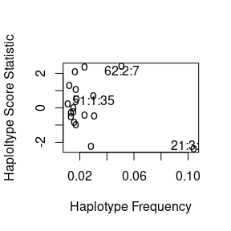

```r
## plot score vs. frequency, gaussian response
plot(score.gaus.add, pch = "o")

## locate and label pts with their haplotypes works similar to locator() function > pts.haplo <-
## locator.haplo(score.gaus)

pts.haplo <- list(x.coord = c(0.05098, 0.03018, 0.1), y.coord = c(2.1582, 0.45725, -2.1566), hap.txt = c("62:2:7",
    "51:1:35", "21:3:8"))

text(x = pts.haplo$x.coord, y = pts.haplo$y.coord, labels = pts.haplo$hap.txt)
```

## Skipping Rare Haplotypes

```r
# increase skip.haplo, expected hap counts = 10
score.gaus.min10 <- haplo.score(hla.demo$resp, geno, trait.type = "gaussian", x.adj = NA, min.count = 10,
    locus.label = genolabel, simulate = FALSE)
print(score.gaus.min10)
```

```
----------------------------------------------------------------------------------------------------
                                  Haplotype Effect Model: additive
----------------------------------------------------------------------------------------------------
----------------------------------------------------------------------------------------------------
                                      Global Score Statistics
----------------------------------------------------------------------------------------------------

global-stat = 20.66451, df = 7, p-val = 0.0043

----------------------------------------------------------------------------------------------------
                                     Haplotype-specific Scores
----------------------------------------------------------------------------------------------------

     DQB DRB B  Hap-Freq Hap-Score p-val
[1,] 21  3   8  0.10408  -2.39631  0.01656
[2,] 31  4   44 0.02849  -2.24273  0.02491
[3,] 32  4   60 0.0306   -0.46606  0.64118
[4,] 21  7   44 0.02332  -0.41942  0.67491
[5,] 51  1   35 0.03018  0.69696   0.48583
[6,] 32  4   62 0.02349  2.37619   0.01749
[7,] 62  2   7  0.05098  2.39795   0.01649
```

# Score Statistic Dependencies: the *eps.svd* parameter

The global score test is calculated using the vector of scores and the generalized inverse of their variance-covariance matrix, performed by the *Ginv* function. This function determines the rank of the variance matrix by its singular value decomposition, and an epsilon value is used as the cut-off for small singular values. If all of the haplotypes in the sample are scored, then there is dependence between them and the variance matrix is not of full rank. However, it is more often the case that one or more rare haplotypes are not scored because of low frequency. It is not clear how strong the dependencies are between the remaining score statistics, and likewise, there is disparity in calculating the rank of the variance matrix. For these instances we give the user control over the epsilon parameter for *haplo.score* with *eps.svd*.

We have seen instances where the global score test had a very significant p-value, but none of the haplotype-specific scores showed strong association. In such instances, we found the default epsilon value in *Ginv* was incorrectly considering the variance matrix as having full rank, and the misleading global score test was corrected with a larger epsilon for *Ginv*.

## Haplotype Model Effect

The *haplo.score()* function allows non-additive effects for scoring haplotypes. The possible effects for haplotypes are additive, dominant, and recessive. Under recessive effects, fewer haplotypes may be scored, because subjects are required to be homozygous for haplotypes. Furthermore, there would have to be *min.count* such persons in the sample to have the recessive effect scored. Therefore, a recessive model should only be used on samples with common haplotypes. In the example below with the gaussian response, set the haplotype effect to dominant using parameter *haplo.effect = ‘’dominant’’*. Notice the results change slightly compared to the *score.gaus.add* results above.

```r
# score w/gaussian, dominant effect

score.gaus.dom <- haplo.score(hla.demo$resp, geno, trait.type = "gaussian", x.adj = NA, min.count = 5,
    haplo.effect = "dominant", locus.label = genolabel, simulate = FALSE)
print(score.gaus.dom, nlines = 10)
```

```
----------------------------------------------------------------------------------------------------
                                  Haplotype Effect Model: dominant
----------------------------------------------------------------------------------------------------
----------------------------------------------------------------------------------------------------
                                      Global Score Statistics
----------------------------------------------------------------------------------------------------

global-stat = 29.56133, df = 18, p-val = 0.04194

----------------------------------------------------------------------------------------------------
                                     Haplotype-specific Scores
----------------------------------------------------------------------------------------------------

      DQB DRB B  Hap-Freq Hap-Score p-val
 [1,] 21  3   8  0.10408  -2.23872  0.02517
 [2,] 31  4   44 0.02849  -2.13233  0.03298
 [3,] 51  1   44 0.01731  -0.99357  0.32043
 [4,] 63  13  44 0.01606  -0.84453  0.39837
 [5,] 63  2   7  0.01333  -0.50736  0.6119
 [6,] 32  4   60 0.0306   -0.46606  0.64118
 [7,] 21  7   44 0.02332  -0.41942  0.67491
 [8,] 62  2   44 0.01367  -0.26221  0.79316
 [9,] 62  2   18 0.01545  -0.21493  0.82982
[10,] 51  1   27 0.01505  0.01539   0.98772
```

## Simulation p-values

When *simulate=TRUE*, *haplo.score* gives simulated p-values.  
Simulated haplotype score statistics are the re-calculated score statistics from a permuted re-ordering of the trait and covariates and the original ordering of the genotype matrix. The simulated p-value for the global score statistic (*Global sim. p-val*) is the number of times the simulated global score statistic exceeds the observed, divided by the total number of simulations. Likewise, simulated p-value for the maximum score statistic (Max-stat sim. p-val*) is the number of times the simulated maximum haplotype score statistic exceeds the observed maximum score statistic, divided by the total number of simulations. The maximum score statistic is the maximum of the square of the haplotype-specific score statistics, which has an unknown distribution, so its significance can only be given by the simulated p-value.  
Intuitively, if only one or two haplotypes are associated with the trait, the maximum score statistic should have greater power to detect association than the global statistic.

```r
# simulations when binary response
score.bin.sim <- haplo.score(y.bin, geno, trait.type = "binomial", x.adj = NA, locus.label = genolabel,
    min.count = 5, simulate = TRUE, sim.control = score.sim.control())
print(score.bin.sim)
```

```
----------------------------------------------------------------------------------------------------
                                  Haplotype Effect Model: additive
----------------------------------------------------------------------------------------------------
----------------------------------------------------------------------------------------------------
                                      Global Score Statistics
----------------------------------------------------------------------------------------------------

global-stat = 33.70125, df = 18, p-val = 0.01371

----------------------------------------------------------------------------------------------------
                                 Global Simulation p-value Results
----------------------------------------------------------------------------------------------------

Global sim. p-val =  0.0095
Max-Stat sim. p-val =  0.00563
Number of Simulations, Global:  2842 , Max-Stat: 2842

----------------------------------------------------------------------------------------------------
                                     Haplotype-specific Scores
----------------------------------------------------------------------------------------------------

      DQB DRB B  Hap-Freq Hap-Score p-val   sim p-val
 [1,] 62  2   7  0.05098  -2.19387  0.02824 0.02991
 [2,] 51  1   35 0.03018  -1.58421  0.11315 0.13863
 [3,] 63  13  7  0.01655  -1.56008  0.11874 0.19177
 [4,] 21  7   7  0.01246  -1.47495  0.14023 0.15588
 [5,] 32  4   7  0.01678  -1.00091  0.31687 0.25123
 [6,] 32  4   62 0.02349  -0.6799   0.49657 0.47467
 [7,] 51  1   27 0.01505  -0.66509  0.50599 0.63089
 [8,] 31  11  35 0.01754  -0.5838   0.55936 0.6506
 [9,] 31  11  51 0.01137  -0.43721  0.66196 0.91872
[10,] 51  1   44 0.01731  0.00826   0.99341 1
[11,] 32  4   60 0.0306   0.03181   0.97462 0.95074
[12,] 62  2   44 0.01367  0.16582   0.8683  0.91872
[13,] 63  13  44 0.01606  0.22059   0.82541 0.7266
[14,] 63  2   7  0.01333  0.2982    0.76555 0.89163
[15,] 62  2   18 0.01545  0.78854   0.43038 0.6608
[16,] 21  7   44 0.02332  0.84562   0.39776 0.39796
[17,] 31  4   44 0.02849  2.50767   0.01215 0.01161
[18,] 21  3   8  0.10408  3.77763   0.00016 0.00035
```

# Regression Models: *haplo.glm*

The *haplo.glm* function computes the regression of a trait on haplotypes, and possibly other covariates and their interactions with haplotypes. We currently support the gaussian, binomial, and Poisson families of traits with their canonical link functions. The effects of haplotypes on the link function can be modeled as either additive, dominant (heterozygotes and homozygotes for a particular haplotype assumed to have equivalent effects), or recessive (homozygotes of a particular haplotype considered to have an alternative effect on the trait). The basis of the algorithm is a two-step iteration process; the posterior probabilities of pairs of haplotypes per subject are used as weights to update the regression coefficients, and the regression coefficients are used to update the haplotype posterior probabilities. See [Lake et al](https://doi.org/10.1159/000071811) for details.

## New and Updated Methods for haplo.glm

We initially wrote *haplo.glm* with a focus on creating a basic print method for results. We have now refined the *haplo.glm* class to look and act as much like a glm class object as possible with methods defined specifically for the *haplo.glm* class. We provide print and summary methods that make use of the corresponding methods for glm and then add extra information for the haplotypes and their frequencies. Furthermore, we have defined for the *haplo.glm* class some of the standard methods for regression fits, including residuals, fitted.values, vcov, and anova. We later describe the challenges that haplotype regression presents with these methods.

## Preparing the *data.frame* for *haplo.glm*

A critical distinction between *haplo.glm* and all other functions in Haplo Stats is that the definition of the regression model follows the S/R formula standard (see *lm* or *glm*). So, a *data.frame* must be defined, and this object must contain the trait and other optional covariates, plus a special kind of genotype matrix (*geno.glm* for this example) that contains the genotypes of the marker loci. We require the genotype matrix to be prepared using *setupGeno()*, which handles character, numeric, or factor alleles, and keeps the columns of the genotype matrix as a single unit when inserting into (and extracting from) a *data.frame*. The *setupGeno* function recodes all missing genotype value codes given by *miss.val* to NA, and also recodes alleles to integer values. The original allele codes are preserved within an attribute of *geno.glm*, and are utilized within *haplo.glm*. The returned object has class *model.matrix*, and it can be included in a *data.frame* to be used in *haplo.glm*. In the example below we prepare a genotype matrix, *geno.glm*, and create a *data.frame* object, *glm.data*, for use in *haplo.glm*.

```r
# set up data for haplo.glm, include geno.glm, covariates age and male, and responses resp and
# y.bin
geno <- hla.demo[, c(17, 18, 21:24)]
geno.glm <- setupGeno(geno, miss.val = c(0, NA), locus.label = genolabel)
attributes(geno.glm)
```

```
$dim
[1] 220   6

$dimnames
$dimnames[[1]]
NULL

$dimnames[[2]]
[1] "DQB.a1" "DQB.a2" "DRB.a1" "DRB.a2" "B.a1"   "B.a2"


$class
[1] "model.matrix"

$unique.alleles
$unique.alleles[[1]]
 [1] "21" "31" "32" "33" "42" "51" "52" "53" "61" "62" "63" "64"

$unique.alleles[[2]]
 [1] "1"  "2"  "3"  "4"  "7"  "8"  "9"  "10" "11" "13" "14"

$unique.alleles[[3]]
 [1] "7"  "8"  "13" "14" "18" "27" "35" "37" "38" "39" "41" "42" "44" "45" "46" "47" "48" "49" "50"
[20] "51" "52" "55" "56" "57" "58" "60" "61" "62" "63" "70"
```

```r
y.bin <- 1 * (hla.demo$resp.cat == "low")
glm.data <- data.frame(geno.glm, age = hla.demo$age, male = hla.demo$male, y = hla.demo$resp, y.bin = y.bin)
```

## Rare Haplotypes

The issue of deciding which haplotypes to use for association is critical in *haplo.glm*. By default it will model a rare haplotype effect so that the effects of other haplotypes are in reference to the baseline effect of the one common happlotype. The rules for choosing haplotypes to be modeled in *haplo.glm* are similar to the rules in *haplo.score*: by a minimum frequency or a minimum expected count in the sample.

Two control parameters in *haplo.glm.control* may be used to control this setting: *haplo.freq.min* may be set to a selected minimum haplotype frequency, and *haplo.min.count* may be set to select the cut-off for minimum expected haplotype count in the sample. The default minimum frequency cut-off in *haplo.glm* is set to $0.01$. More discussion on rare haplotypes is included later.

## Regression for a Quantitative Trait

The following illustrates how to fit a regression of a quantitative trait *y* on the haplotypes estimated from the *geno.glm* matrix, and the covariate *male*. For *na.action*, we use *na.geno.keep*, which keeps a subject with missing values in the genotype matrix if they are not missing all alleles, but removes subjects with missing values (*NA*) in either the response or covariate.

```r
# glm fit with haplotypes, additive gender covariate on gaussian response
fit.gaus <- haplo.glm(y ~ male + geno.glm, family = gaussian, data = glm.data, na.action = "na.geno.keep",
    locus.label = genolabel, x = TRUE, control = haplo.glm.control(haplo.freq.min = 0.02))

summary(fit.gaus)
```

```
Call:
haplo.glm(formula = y ~ male + geno.glm, family = gaussian, data = glm.data,
    na.action = "na.geno.keep", locus.label = genolabel, control = haplo.glm.control(haplo.freq.min = 0.02),
    x = TRUE)

Coefficients:
                  coef       se   t.stat  pval
(Intercept)    1.06436  0.34283  3.10464 0.002
male           0.09735  0.15521  0.62723 0.531
geno.glm.17    0.28022  0.43549  0.64346 0.521
geno.glm.34   -0.31713  0.34342 -0.92342 0.357
geno.glm.77    0.22167  0.36126  0.61360 0.540
geno.glm.78    1.14144  0.38382  2.97390 0.003
geno.glm.100   0.55557  0.36427  1.52517 0.129
geno.glm.138   0.98229  0.30329  3.23875 0.001
geno.glm.rare  0.39765  0.18191  2.18591 0.030

(Dispersion parameter for gaussian family taken to be 1.269581)

    Null deviance: 297.01  on 219  degrees of freedom
Residual deviance: 267.88  on 211  degrees of freedom
AIC: 687.65

Number of Fisher Scoring iterations: 268


Haplotypes:
              DQB DRB  B hap.freq
geno.glm.17    21   7 44  0.02291
geno.glm.34    31   4 44  0.02858
geno.glm.77    32   4 60  0.03022
geno.glm.78    32   4 62  0.02390
geno.glm.100   51   1 35  0.03008
geno.glm.138   62   2  7  0.05023
geno.glm.rare   *   *  *  0.71000
haplo.base     21   3  8  0.10409
```

## Fitting Haplotype x Covariate Interactions

Interactions are fit by the standard S-language model syntax, using a ‘$*$’ in the model formula to indicate main effects and interactions. Some other formula constructs are not supported, so use the formula parameter with caution. Below is an example of modeling the interaction of *male* and the haplotypes. Because more terms will be estimated in this case, we limit how many haplotypes will be included by increasing *haplo.min.count* to 10.

```r
# glm fit haplotypes with covariate interaction
fit.inter <- haplo.glm(formula = y ~ male * geno.glm, family = gaussian, data = glm.data, na.action = "na.geno.keep",
    locus.label = genolabel, control = haplo.glm.control(haplo.min.count = 10))
summary(fit.inter)
```

```
Call:
haplo.glm(formula = y ~ male * geno.glm, family = gaussian, data = glm.data,
    na.action = "na.geno.keep", locus.label = genolabel, control = haplo.glm.control(haplo.min.count = 10))

Coefficients:
                       coef       se   t.stat  pval
(Intercept)         0.97536  0.52268  1.86607 0.063
male                0.25806  0.67351  0.38315 0.702
geno.glm.17         0.14443  0.54544  0.26479 0.791
geno.glm.34        -0.17161  0.66773 -0.25700 0.797
geno.glm.77         0.80523  0.64951  1.23975 0.216
geno.glm.78         0.49557  0.56574  0.87596 0.382
geno.glm.100        0.52310  0.48067  1.08828 0.278
geno.glm.138        1.15704  0.42325  2.73371 0.007
geno.glm.rare       0.45547  0.28721  1.58587 0.114
male:geno.glm.17    0.50872  0.87531  0.58119 0.562
male:geno.glm.34   -0.28137  0.78570 -0.35812 0.721
male:geno.glm.77   -0.90084  0.79114 -1.13865 0.256
male:geno.glm.78    1.26376  0.77131  1.63846 0.103
male:geno.glm.100   0.05074  0.77470  0.06549 0.948
male:geno.glm.138  -0.44587  0.61903 -0.72027 0.472
male:geno.glm.rare -0.09787  0.37197 -0.26312 0.793

(Dispersion parameter for gaussian family taken to be 1.27362)

    Null deviance: 297.01  on 219  degrees of freedom
Residual deviance: 259.82  on 204  degrees of freedom
AIC: 694.93

Number of Fisher Scoring iterations: 120


Haplotypes:
              DQB DRB  B hap.freq
geno.glm.17    21   7 44  0.02346
geno.glm.34    31   4 44  0.02845
geno.glm.77    32   4 60  0.03060
geno.glm.78    32   4 62  0.02413
geno.glm.100   51   1 35  0.03013
geno.glm.138   62   2  7  0.05049
geno.glm.rare   *   *  *  0.70863
haplo.base     21   3  8  0.10410
```

The listed results similar as explained above. The main difference is that the interaction coefficients are labeled as a concatenation of the covariate (*male* in this example) and the name of the haplotype, as described above. In addition, estimates may differ because the model has changed.

## Regression for a Binomial Trait

Next we illustrate the fitting of a binomial trait with the same genotype matrix and covariate.

```r
# gender and haplotypes fit on binary response, return model matrix
fit.bin <- haplo.glm(y.bin ~ male + geno.glm, family = binomial, data = glm.data, na.action = "na.geno.keep",
    locus.label = genolabel, control = haplo.glm.control(haplo.min.count = 10))
summary(fit.bin)
```

```
Call:
haplo.glm(formula = y.bin ~ male + geno.glm, family = binomial,
    data = glm.data, na.action = "na.geno.keep", locus.label = genolabel,
    control = haplo.glm.control(haplo.min.count = 10))

Coefficients:
                 coef      se  t.stat  pval
(Intercept)    1.5457  0.6547  2.3610 0.019
male          -0.4802  0.3308 -1.4518 0.148
geno.glm.17   -0.7227  0.8011 -0.9022 0.368
geno.glm.34    0.3641  0.6798  0.5356 0.593
geno.glm.77   -0.9884  0.7328 -1.3489 0.179
geno.glm.78   -1.4093  0.8543 -1.6496 0.101
geno.glm.100  -2.5907  1.1278 -2.2971 0.023
geno.glm.138  -2.7156  0.8524 -3.1860 0.002
geno.glm.rare -1.2610  0.3537 -3.5647 0.000

(Dispersion parameter for binomial family taken to be 1)

    Null deviance: 263.50  on 219  degrees of freedom
Residual deviance: 233.46  on 211  degrees of freedom
AIC: 251.11

Number of Fisher Scoring iterations: 61


Haplotypes:
              DQB DRB  B hap.freq
geno.glm.17    21   7 44  0.02303
geno.glm.34    31   4 44  0.02843
geno.glm.77    32   4 60  0.03057
geno.glm.78    32   4 62  0.02354
geno.glm.100   51   1 35  0.02977
geno.glm.138   62   2  7  0.05181
geno.glm.rare   *   *  *  0.70880
haplo.base     21   3  8  0.10405
```

The underlying methods for *haplo.glm* are based on a prospective likelihood. Normally, this type of likelihood works well for case-control studies with standard covariates. For ambiguous haplotypes, however, one needs to be careful when interpreting the results from fitting *haplo.glm* to case-control data. Because cases are over-sampled, relative to the population prevalence (or incidence, for incident cases), haplotypes associated with disease will be over-represented in the case sample, and so estimates of haplotype frequencies will be biased. Positively associated haplotypes will have haplotype frequency estimates that are higher than the population haplotype frequency. To avoid this problem, one can weight each subject. The weights for the cases should be the population prevalence, and the weights for controls should be 1 (assuming the disease is rare in the population, and controls are representative of the general population). See [Stram et al. 2003](https://doi.org/10.1159/000073202) for background on using weights, and see the help file for *haplo.glm* for how to implement weights.

The estimated regression coefficients for case-control studies can be biased by either a large amount of haplotype ambiguity and mis-specified weights, or by departures from Hardy-Weinberg Equilibrium of the haplotypes in the pool of cases and controls. Generally, the bias is small, but tends to be towards the null of no association. See [Stram et al. 2003](https://doi.org/10.1159/000073202) and [Epstein and Satten, 2003](https://doi.org/10.1086/380204) for further details.

### Caution on Rare Haplotypes with Binomial Response

If a rare haplotype occurs only in cases or only in controls, the fitted values would go to 0 or 1, where R would issue a warning. Also, the coefficient estimate for that haplotype would go to positive or negative infinity, If the default *haplo.min.count=5* were used above, this warning would appear. To keep this from occuring in other model fits, increase the minimum count or minimum frequency.

## Control Parameters

Additional parameters are handled using *control*, which is a list of parameters providing additional functionality in *haplo.glm*. This list is set up by the function *haplo.glm.control*. See the help file (*help(haplo.glm.control)*) for a full list of control parameters, with details of their usage. Some of the options are described here.

## Controlling Genetic Models: *haplo.effect*

Note that in a recessive model, the haplotype effects are estimated only from subjects who are homozygous for a haplotype. Some of the haplotypes which meet the *haplo.freq.min* and *haplo.count.min* cut-offs may occur as homozygous in only a few of the subjects. As stated above, recessive models should be used when the region has multiple common haplotypes.

The default *haplo.effect* is *additive*, whereas the example below illustrates the fit of a *dominant* effect of haplotypes for the gaussian trait with the gender covariate.

```r
# control dominant effect of haplotypes (haplo.effect) by using haplo.glm.control
fit.dom <- haplo.glm(y ~ male + geno.glm, family = gaussian, data = glm.data, na.action = "na.geno.keep",
    locus.label = genolabel, control = haplo.glm.control(haplo.effect = "dominant", haplo.min.count = 8))

summary(fit.dom)
```

```
Call:
haplo.glm(formula = y ~ male + geno.glm, family = gaussian, data = glm.data,
    na.action = "na.geno.keep", locus.label = genolabel, control = haplo.glm.control(haplo.effect = "dominant",
        haplo.min.count = 8))

Coefficients:
                  coef       se   t.stat  pval
(Intercept)    1.64935  0.37350  4.41593 0.000
male           0.07969  0.15726  0.50673 0.613
geno.glm.17   -0.06035  0.42317 -0.14262 0.887
geno.glm.34   -0.66499  0.36392 -1.82731 0.069
geno.glm.77   -0.07339  0.34665 -0.21171 0.833
geno.glm.78    0.85369  0.36421  2.34394 0.020
geno.glm.100   0.24697  0.34561  0.71458 0.476
geno.glm.138   0.67295  0.28163  2.38944 0.018
geno.glm.rare  0.11195  0.34006  0.32922 0.742

(Dispersion parameter for gaussian family taken to be 1.300586)

    Null deviance: 297.01  on 219  degrees of freedom
Residual deviance: 274.42  on 211  degrees of freedom
AIC: 692.96

Number of Fisher Scoring iterations: 91


Haplotypes:
              DQB DRB  B hap.freq
geno.glm.17    21   7 44  0.02297
geno.glm.34    31   4 44  0.02855
geno.glm.77    32   4 60  0.03019
geno.glm.78    32   4 62  0.02391
geno.glm.100   51   1 35  0.03003
geno.glm.138   62   2  7  0.05023
geno.glm.rare   *   *  *  0.71003
haplo.base     21   3  8  0.10408
```

### Selecting the Baseline Haplotype

The haplotype chosen for the baseline in the model is the one with the highest frequency. Sometimes the most frequent haplotype may be an at-risk haplotype, and so the measure of its effect is desired. To specify a more appropriate haplotype as the baseline in the binomial example, choose from the list of other common haplotypes, *fit.bin$haplo.common*. To specify an alternative baseline, such as haplotype 77, use the control parameter *haplo.base* and haplotype code, as in the example below.

```r
# control baseline selection, perform the same exact run as fit.bin, but different baseline by
# using haplo.base chosen from haplo.common
fit.bin$haplo.common
```

```
[1]  17  34  77  78 100 138
```

```r
fit.bin$haplo.freq.init[fit.bin$haplo.common]
```

```
[1] 0.02332031 0.02848720 0.03060053 0.02349463 0.03018431 0.05097906
```

```r
fit.bin.base77 <- haplo.glm(y.bin ~ male + geno.glm, family = binomial, data = glm.data, na.action = "na.geno.keep",
    locus.label = genolabel, control = haplo.glm.control(haplo.base = 77, haplo.min.count = 8))
summary(fit.bin.base77)
```

```
Call:
haplo.glm(formula = y.bin ~ male + geno.glm, family = binomial,
    data = glm.data, na.action = "na.geno.keep", locus.label = genolabel,
    control = haplo.glm.control(haplo.base = 77, haplo.min.count = 8))

Coefficients:
                 coef      se  t.stat  pval
(Intercept)   -0.4311  1.3586 -0.3173 0.751
male          -0.4802  0.3308 -1.4518 0.148
geno.glm.4     0.9884  0.7328  1.3489 0.179
geno.glm.17    0.2657  1.0254  0.2591 0.796
geno.glm.34    1.3525  0.9223  1.4665 0.144
geno.glm.78   -0.4209  1.0430 -0.4035 0.687
geno.glm.100  -1.6023  1.3007 -1.2319 0.219
geno.glm.138  -1.7273  1.0321 -1.6736 0.096
geno.glm.rare -0.2726  0.6834 -0.3989 0.690

(Dispersion parameter for binomial family taken to be 1)

    Null deviance: 263.50  on 219  degrees of freedom
Residual deviance: 233.46  on 211  degrees of freedom
AIC: 251.11

Number of Fisher Scoring iterations: 61


Haplotypes:
              DQB DRB  B hap.freq
geno.glm.4     21   3  8  0.10405
geno.glm.17    21   7 44  0.02303
geno.glm.34    31   4 44  0.02843
geno.glm.78    32   4 62  0.02354
geno.glm.100   51   1 35  0.02977
geno.glm.138   62   2  7  0.05181
geno.glm.rare   *   *  *  0.70880
haplo.base     32   4 60  0.03057
```

The above model has the same haplotypes as *fit.bin*, except haplotype $4$, the old baseline, now has an effect estimate while haplotype $77$ is the new baseline. Due to randomness in the starting values of the haplotype frequency estimation, different runs of *haplo.glm* may result in a different set of haplotypes meeting the minimum counts requirement for being modeled. Therefore, once you have arrived at a suitable model, and you wish to modify it by changing baseline and/or effects, you can make results consistent by controlling the randomness using *set.seed*. In this document, we use the same seed before making *fit.bin* and *fit.bin.base77*.

### Rank of Information Matrix and eps.svd

```r
glm.data$ybig <- glm.data$y * 50
fit.gausbig <- haplo.glm(formula = ybig ~ male + geno.glm, family = gaussian, data = glm.data, na.action = "na.geno.keep",
    locus.label = genolabel, control = haplo.glm.control(haplo.freq.min = 0.02), x = TRUE)

summary(fit.gausbig)
```

```
Call:
haplo.glm(formula = ybig ~ male + geno.glm, family = gaussian,
    data = glm.data, na.action = "na.geno.keep", locus.label = genolabel,
    control = haplo.glm.control(haplo.freq.min = 0.02), x = TRUE)

Coefficients:
                  coef       se   t.stat  pval
(Intercept)    53.2180   1.7343  30.6849 0.000
male            4.8675   6.0042   0.8107 0.418
geno.glm.17    14.0111   0.2579  54.3195 0.000
geno.glm.34   -15.8563   1.0033 -15.8044 0.000
geno.glm.77    11.0835   0.9978  11.1078 0.000
geno.glm.78    57.0720   0.3855 148.0436 0.000
geno.glm.100   27.7784   0.3228  86.0564 0.000
geno.glm.138   49.1143   1.0334  47.5256 0.000
geno.glm.rare  19.8824   3.4583   5.7493 0.000

(Dispersion parameter for gaussian family taken to be 3173.952)

    Null deviance: 742530  on 219  degrees of freedom
Residual deviance: 669704  on 211  degrees of freedom
AIC: 2408.9

Number of Fisher Scoring iterations: 268


Haplotypes:
              DQB DRB  B hap.freq
geno.glm.17    21   7 44  0.02291
geno.glm.34    31   4 44  0.02858
geno.glm.77    32   4 60  0.03022
geno.glm.78    32   4 62  0.02390
geno.glm.100   51   1 35  0.03008
geno.glm.138   62   2  7  0.05023
geno.glm.rare   *   *  *  0.71000
haplo.base     21   3  8  0.10409
```

```r
fit.gausbig$rank.info
```

```
[1] 175
```

```r
fit.gaus$rank.info
```

```
[1] 182
```

Now we set a smaller value for the *eps.svd* control parameter and find the fit matches the original Gaussian fit.

```r
fit.gausbig.eps <- haplo.glm(formula = ybig ~ male + geno.glm, family = gaussian, data = glm.data, na.action = "na.geno.keep",
    locus.label = genolabel, control = haplo.glm.control(eps.svd = 1e-10, haplo.freq.min = 0.02), x = TRUE)

summary(fit.gausbig.eps)
```

```
Call:
haplo.glm(formula = ybig ~ male + geno.glm, family = gaussian,
    data = glm.data, na.action = "na.geno.keep", locus.label = genolabel,
    control = haplo.glm.control(eps.svd = 1e-10, haplo.freq.min = 0.02),
    x = TRUE)

Coefficients:
                  coef       se   t.stat  pval
(Intercept)    53.2180  17.1414   3.1046 0.002
male            4.8675   7.7603   0.6272 0.531
geno.glm.17    14.0111  21.7745   0.6435 0.521
geno.glm.34   -15.8563  17.1712  -0.9234 0.357
geno.glm.77    11.0835  18.0631   0.6136 0.540
geno.glm.78    57.0720  19.1910   2.9739 0.003
geno.glm.100   27.7784  18.2133   1.5252 0.129
geno.glm.138   49.1143  15.1646   3.2387 0.001
geno.glm.rare  19.8824   9.0957   2.1859 0.030

(Dispersion parameter for gaussian family taken to be 3173.952)

    Null deviance: 742530  on 219  degrees of freedom
Residual deviance: 669704  on 211  degrees of freedom
AIC: 2408.9

Number of Fisher Scoring iterations: 268


Haplotypes:
              DQB DRB  B hap.freq
geno.glm.17    21   7 44  0.02291
geno.glm.34    31   4 44  0.02858
geno.glm.77    32   4 60  0.03022
geno.glm.78    32   4 62  0.02390
geno.glm.100   51   1 35  0.03008
geno.glm.138   62   2  7  0.05023
geno.glm.rare   *   *  *  0.71000
haplo.base     21   3  8  0.10409
```

```r
fit.gausbig.eps$rank.info
```

```
[1] 182
```

### Rare Haplotypes and *haplo.min.info*

Another notable control parameter is the minimum frequency for a rare haplotype to be included in the calculations for standard error (se) of the coefficients, or *haplo.min.info*. The default value is $0.001$, which means that haplotypes with frequency less than that will be part of the rare haplotype coefficient estimate, but it will not be used in the standard error calculation.

The following example demonstrates a possible result when dealing with the rare haplotype effect. We show with the hla genotype data one consequence for when this occurs. However, we make it happen by setting *haplo.freq.min* equal to *haplo.min.info*, which we advise strongly against in your analyses.

```r
## set haplo.freq.min and haplo.min.info to same value to show how the rare coefficient may be
## modeled but standard error estimate is not calculated because all haps are below haplo.min.info
## warning expected
fit.bin.rare02 <- haplo.glm(y.bin ~ geno.glm, family = binomial, data = glm.data, na.action = "na.geno.keep",
    locus.label = genolabel, control = haplo.glm.control(haplo.freq.min = 0.02, haplo.min.info = 0.02))
summary(fit.bin.rare02)
```

```
Call:
haplo.glm(formula = y.bin ~ geno.glm, family = binomial, data = glm.data,
    na.action = "na.geno.keep", locus.label = genolabel, control = haplo.glm.control(haplo.freq.min = 0.02,
        haplo.min.info = 0.02))

Coefficients:
                 coef      se  t.stat  pval
(Intercept)    1.2409  1.3238  0.9374 0.350
geno.glm.17   -0.6068  1.5630 -0.3882 0.698
geno.glm.34    0.3189  1.2678  0.2516 0.802
geno.glm.77   -1.0719  1.3666 -0.7844 0.434
geno.glm.78   -1.3593  4.3659 -0.3113 0.756
geno.glm.100  -2.3984  2.0878 -1.1487 0.252
geno.glm.138  -2.6096  1.5043 -1.7347 0.084
geno.glm.rare -1.2233     NaN     NaN   NaN

(Dispersion parameter for binomial family taken to be 1)

    Null deviance: 263.50  on 219  degrees of freedom
Residual deviance: 235.59  on 212  degrees of freedom
AIC: 251.24

Number of Fisher Scoring iterations: 71


Haplotypes:
              DQB DRB  B hap.freq
geno.glm.17    21   7 44  0.02302
geno.glm.34    31   4 44  0.02841
geno.glm.77    32   4 60  0.03058
geno.glm.78    32   4 62  0.02353
geno.glm.100   51   1 35  0.02980
geno.glm.138   62   2  7  0.05190
geno.glm.rare   *   *  *  0.70872
haplo.base     21   3  8  0.10403
```

The above results show the standard error for the rare haplotype coefficient is `NaN'', or`Not a Number’’ in R, which is a consequence of having most, or all, of the rare haplotypes discarded for the standard error estimate. In other datasets there may be only a few haplotypes between *haplo.min.info* and *haplo.freq.min*, and may yield misleading results for the rare haplotype coefficient. For this reason, we recommend that any inference made on the rare haplotypes be made with caution, if at all.

# Methods for *haplo.glm*

After the introduction of *haplo.glm*, the package was updated with methods to allow it to act similar to a glm object with methods to compare and assess model fits. In this section we describe the challenges and caveats of defining these methods for a *haplo.glm* object and show how to use them.

## fitted.values

A challenge when defining methods for *haplo.glm* is that we account for the ambiguity in a sample haplotype pair. To handle this in the glm framework, the response and non-haplotype covariates are expanded for each person with a posterior probability of the haplotype given their genotype as a weight.  
The returned object from *haplo.glm* looks somewhat like a regular glm, but the model matrix, response, and thus the fitted values, are all expanded.  
Users who want to work with the expanded versions of those items are welcome to access them from the returned object.

We now provide a method to get the fitted values for each person, *fitted.haplo.glm*. These collapsed fitted values are calculated by a weighted sum of the expanded fitted values for each person where the weights are the posterior probabilities of the sample expanded haplotype pairs.

## residuals

The residuals within the *haplo.glm* object are also expanded for the haplotype pairs for subjects. We provide *residuals.haplo.glm* to get the collapsed deviance, pearson, working, and response residuals for each person. Because we have not implemented a predict method for *haplo.glm*, the method does not calculate partial residuals.

## vcov

We provide *vcov.haplo.glm* as a method to get the variance-covariance matrix of model parameters in the *haplo.glm* object. Unlike the standard glm object, this matrix is computed and retained in the returned object. We do this because the model parameters are the model coefficients and the haplotype frequencies, and it is computationally-intensive to compute.

We show how to get the variance matrix for all the parameters and for only the model coefficients.

```r
varmat <- vcov(fit.gaus)
dim(varmat)
```

```
[1] 182 182
```

```r
varmat <- vcov(fit.gaus, freq = FALSE)
dim(varmat)
```

```
[1] 9 9
```

```r
print(varmat, digits = 2)
```

```
              (Intercept)     male geno.glm.17 geno.glm.34 geno.glm.77 geno.glm.78 geno.glm.100
(Intercept)         0.118 -0.01513     -0.0674     -0.0544     -0.0526    -0.05123      -0.0595
male               -0.015  0.02409      0.0065     -0.0022     -0.0038     0.00082       0.0067
geno.glm.17        -0.067  0.00646      0.1897      0.0335      0.0206     0.03217       0.0370
geno.glm.34        -0.054 -0.00218      0.0335      0.1179      0.0226     0.02753       0.0298
geno.glm.77        -0.053 -0.00375      0.0206      0.0226      0.1305     0.02602       0.0204
geno.glm.78        -0.051  0.00082      0.0322      0.0275      0.0260     0.14732       0.0285
geno.glm.100       -0.059  0.00674      0.0370      0.0298      0.0204     0.02853       0.1327
geno.glm.138       -0.059  0.00362      0.0307      0.0254      0.0256     0.02195       0.0214
geno.glm.rare      -0.058  0.00142      0.0320      0.0283      0.0278     0.02478       0.0281
              geno.glm.138 geno.glm.rare
(Intercept)        -0.0587       -0.0583
male                0.0036        0.0014
geno.glm.17         0.0307        0.0320
geno.glm.34         0.0254        0.0283
geno.glm.77         0.0256        0.0278
geno.glm.78         0.0220        0.0248
geno.glm.100        0.0214        0.0281
geno.glm.138        0.0920        0.0288
geno.glm.rare       0.0288        0.0331
```

## anova and Model Comparison

We use the *anova.glm* method as a framework for *anova.haplo.glm* to allow comparisons of model fits. We limit the model comparisons to multiple nested model fits, which requires that each model to be compared is either a *haplo.glm* or *glm* fitted object. We eliminate the functionality of testing sub-models of a single fit because removal of a single covariate would require re-fitting of the reduced model to get updated coefficient and haplotype frequency estimates with a maximized log-likelihood. We decided to simplify the usage and require that all models to be compared are fully fitted.

As with the *anova.glm* method, it is difficult to check for truly nested models, so we pass the responsibility on to the user. We discuss some of the requirements.

One type of two-model comparison is between models with haplotypes (expanded subjects) and a reduced model without haplotypes. We check for the same sample size in these models by comparing the collapsed sample size from a *haplo.glm* fit to the sample size from the *glm* fit, which we remind users is only a loose check of model comparability.

The other comparison of two models in *anova.haplo.glm* is to compare two models that contain the same genotypes, and inherently the same haplotypes. This is more tricky because a subject may not have the same expanded set of possible haplotype pairs across two fits of *haplo.glm* unless the same seed is set before both fits. Even if a seed is the same, the other effects that are different between the two models will affect the haplotype frequency estimates, and may still result in a different expansion of haplotype pairs per subject. Our check of the collapsed sample size for the two models still applies with the same pitfalls, but a better assurance of model comparability is to use the same seed.

In the *haplo.glm* fit we provide the likelihood ratio test of the null model against the full model, which is the most appropriate test available for *haplo.glm* objects, but it is difficult to compare the log-likeihood across two *haplo.glm* fits. Therefore, we remain consistent with glm model comparison proposed by McCullagh and Nelder, 1989, and use the difference in deviance to compare models. Furthermore, we restrict the asymptotic test for model comparison to be the $\chi^{2}$ test for goodness of fit.

Below we show how to get the LRT from the *fit.gaus* result, then show how to compare some of the nested models fit above, including a regular glm fit of $y \sim male$. The anova method requires the nested model to be given first, and any anova with a *haplo.glm* object should explicitly call *anova.haplo.glm*.

```r
fit.gaus$lrt
```

```
$lrt
[1] 22.34062

$df
[1] 8
```

```r
glmfit.gaus <- glm(y ~ male, family = "gaussian", data = glm.data)

anova.haplo.glm(glmfit.gaus, fit.gaus)
```

```
Analysis of Deviance Table

Model 1: y ~ male
Model 2: y ~ male + geno.glm
  Resid. Df Resid. Dev Df Deviance Pr(>Chi)
1       218     297.00
2       211     267.88  7   29.114 0.001752 **
---
Signif. codes:  0 '***' 0.001 '**' 0.01 '*' 0.05 '.' 0.1 ' ' 1
```

```r
anova.haplo.glm(fit.gaus, fit.inter)
```

```
Analysis of Deviance Table

Model 1: y ~ male + geno.glm
Model 2: y ~ male * geno.glm
  Resid. Df Resid. Dev Df Deviance Pr(>Chi)
1       211     267.88
2       204     259.82  7   8.0631   0.5017
```

```r
anova.haplo.glm(glmfit.gaus, fit.gaus, fit.inter)
```

```
Analysis of Deviance Table

Model 1: y ~ male
Model 2: y ~ male + geno.glm
Model 3: y ~ male * geno.glm
  Resid. Df Resid. Dev Df Deviance Pr(>Chi)
1       218     297.00
2       211     267.88  7  29.1137 0.001804 **
3       204     259.82  7   8.0631 0.501696
---
Signif. codes:  0 '***' 0.001 '**' 0.01 '*' 0.05 '.' 0.1 ' ' 1
```

# Extended Applications

The following functions are designed to wrap the functionality of the major functions in Haplo Stats into other useful applications.

## Combine Score and Group Results: *haplo.score.merge*

When analyzing a qualitative trait, such as binary, it can be helpful to align the results from *haplo.score* with *haplo.group*. To do so, use the function *haplo.score.merge*, as illustrated in the following example:

```r
# merge haplo.score and haplo.group results
merge.bin <- haplo.score.merge(score.bin, group.bin)
print(merge.bin, nlines = 10)
```

```
----------------------------------------------------------------------------------------------------
                        Haplotype Scores, p-values, and Frequencies By Group
----------------------------------------------------------------------------------------------------
   DQB DRB  B Hap.Score   p.val Hap.Freq y.bin.0 y.bin.1
1   62   2  7  -2.19387 0.02824  0.05098 0.06789 0.01587
2   51   1 35  -1.58421 0.11315  0.03018 0.03754 0.00907
3   63  13  7  -1.56008 0.11874  0.01655 0.02176      NA
4   21   7  7  -1.47495 0.14023  0.01246 0.01969      NA
5   32   4  7  -1.00091 0.31687  0.01678 0.02628 0.00794
6   32   4 62  -0.67990 0.49657  0.02349 0.01911      NA
7   51   1 27  -0.66509 0.50599  0.01505 0.01855 0.00907
8   31  11 35  -0.58380 0.55936  0.01754 0.01982 0.01587
9   31  11 51  -0.43721 0.66196  0.01137 0.01321      NA
10  51   1 44   0.00826 0.99341  0.01731 0.01595 0.00000
```

## Case-Control Haplotype Analysis: *haplo.cc*

We provide *haplo.cc* to run and combine the results of *haplo.score*, *haplo.group*, and *haplo.glm* for case-control data. The function peforms a score test and a glm on the same haplotypes. The parameters that determine which haplotypes are used are *haplo.min.count* and *haplo.freq.min*,  
which are set in the *control* parameter, as done for *haplo.glm*.

Below we run *haplo.cc* setting the minimum haplotype frequency at $0.02$. The print results are shown, in addition to the names of the objects stored in the *cc.hla* result.

```r
# demo haplo.cc where haplo.min.count is specified use geno, and this function prepares it for
# haplo.glm
y.bin <- 1 * (hla.demo$resp.cat == "low")
cc.hla <- haplo.cc(y = y.bin, geno = geno, locus.label = genolabel, control = haplo.glm.control(haplo.freq.min = 0.02))

print(cc.hla, nlines = 25, digits = 2)
```

```
----------------------------------------------------------------------------------------------------
                                      Global Score Statistics
----------------------------------------------------------------------------------------------------
global-stat = 27, df = 7, p-val = 3e-04

----------------------------------------------------------------------------------------------------
                                   Counts for Cases and Controls
----------------------------------------------------------------------------------------------------
control    case
    157      63

    DQB DRB  B Hap-Score   p-val pool.hf control.hf case.hf glm.eff OR.lower    OR OR.upper
188  62   2  7    -2.185 0.02892  0.0507     0.0682  0.0159     Eff    0.014 0.074     0.39
126  51   1 35    -1.584 0.11314  0.0302     0.0376  0.0089     Eff    0.010 0.092     0.81
98   32   4 62    -0.680 0.49658  0.0235     0.0255      NA     Eff    0.049 0.258     1.37
```

[output cut: 22 more lines]

```r
names(cc.hla)
```

```
[1] "cc.df"        "group.count"  "score.lst"    "fit.lst"      "ci.prob"      "exclude.subj"
```

First, from the names function we see that *cc.hla* also contains *score.lst* and *fit.lst*, which are the *haplo.score* and *haplo.glm* objects, respectively. For the printed results of *haplo.cc*, first are the global statistics from *haplo.score*, followed by cell counts for cases and controls. The last portion of the output is a data frame containing combined results for individual haplotypes:

Significance levels are indicated by the p-values for the score statistics, and the odds ratio (OR) confidence intervals for the haplotype effects. Note that the Odds Ratios are effect sizes of haplotypes, assuming haplotype effects are multiplicative. Since this last table has many columns, lines are wrapped in the output in this manual. You can align wrapped lines by the haplotype code which appears on the far left. Alternatively, instruct the print function to only print *digits* significant digits, and set the width settings for output in your session using the *options()* function.

## Score Tests on Sub-Haplotypes: *haplo.score.slide*

To evaluate the association of sub-haplotypes (subsets of alleles from the full haplotype) with a trait, the user can evaluate a “window” of alleles by *haplo.score*, and slide this window across the entire haplotype. This procedure is implemented by the function *haplo.score.slide*. The run-time is considerably longer for this method, because many re-runs of haplo.em are performed. For this reason, we show only example code using all 11 loci in the demo data, *hla.demo*.

First, make the geno matrix and the locus labels for the 11 loci. Then use *haplo.score.slide* for a window of 3 loci (*n.slide=3*), which will slide along the haplotype for all 9 contiguous subsets of size 3, using the previously defined gaussian trait *resp*.

```r
# haplo.score on 11 loci, slide on 3 consecutive loci at a time
geno.11 <- hla.demo[, -c(1:4)]
label.11 <- c("DPB", "DPA", "DMA", "DMB", "TAP1", "TAP2", "DQB", "DQA", "DRB", "B", "A")
score.slide.gaus <- haplo.score.slide(hla.demo$resp, geno.11, trait.type = "gaussian", n.slide = 3, min.count = 5,
    locus.label = label.11)
print(score.slide.gaus)
```

### Plot Results from *haplo.score.slide*

```r
# plot global p-values for sub-haplotypes from haplo.score.slide
plot.haplo.score.slide(score.slide.gaus)
```

## Creating Haplotype Effect Columns: *haplo.design*

In some instances, the desired model for haplotype effects is not possible with the methods given in *haplo.glm*. Examples include modeling just one haplotype effect, or modeling an interaction of haplotypes from different chromosomes, or analyzing censored data. To circumvent these limitations, we provide a function called *haplo.design*, which will set up an expected haplotype design matrix from a *haplo.em* object, to create columns that can be used to model haplotype effects in other modeling functions.

The function *haplo.design* first creates a design marix for all pairs of haplotypes over all subjects, and then uses the posterior probabilities to create a weighted average contribution for each subject, so that the number of rows of the final design matrix is equal to the number of subjects. This is sometimes called the expectation-substitution method, as proposed by [Zaykin et al. 2002](https://doi.org/10.1159/000057986), and using this haplotype design matrix in a regression model is asymptotically equivalent to the score statistics from *haplo.score* [Xie and Stram 2005](https://doi.org/10.1002/gepi.20087). Although this provides much flexibility, by using the design matrix in any type of regression model, the estimated regression parameters can be biased toward zero [see Lin and Zeng, 2006](https://doi.org/10.1198/016214505000000808) for concerns about the expectation-substitution method).

In the first example below, using default parameters, the returned data.frame contains a column for each haplotype that meets a minimum count in the sample *min.count*. The columns are named by the code they are assigned in *haplo.em*.

```r
# create a matrix of haplotype effect columns from haplo.em result
hap.effect.frame <- haplo.design(save.em)

names(hap.effect.frame)
```

```
 [1] "hap.4"   "hap.13"  "hap.17"  "hap.34"  "hap.50"  "hap.55"  "hap.69"  "hap.77"  "hap.78"
[10] "hap.99"  "hap.100" "hap.102" "hap.138" "hap.140" "hap.143" "hap.155" "hap.162" "hap.165"
```

```r
hap.effect.frame[1:10, 1:8]
```

```
   hap.4    hap.13    hap.17 hap.34 hap.50 hap.55 hap.69 hap.77
1      0 0.0000000 0.0000000      0      0      0      0      0
2      0 0.1253234 0.8746766      0      0      0      0      0
3      0 0.0000000 0.0000000      0      0      0      0      0
4      0 0.2862131 0.7137869      0      0      0      0      0
5      0 0.0000000 0.0000000      0      0      1      0      0
6      1 0.0000000 1.0000000      0      0      0      0      0
7      0 0.0000000 0.0000000      0      0      0      0      0
8      0 0.0000000 0.0000000      0      0      0      0      0
9      0 0.0000000 0.0000000      0      0      0      0      0
10     0 0.0000000 0.0000000      0      0      0      0      0
```

This second example below creates columns for specific haplotype codes that were most interesting in *score.gaus.add*, haplotypes with alleles 21-3-8 and 62-2-7, corresponding to codes 4 and 138 in *haplo.em*, respectively. Assume we want to test their individual effects when they are coded with *haplo.effect=‘’dominant’’*.

```r
# create haplotype effect cols for haps 4 and 138
hap4.hap138.frame <- haplo.design(save.em, hapcodes = c(4, 138), haplo.effect = "dominant")

hap4.hap138.frame[1:10, ]
```

```
   hap.4   hap.138
1      0 0.0000000
2      0 0.8746766
3      0 0.0000000
4      0 0.0000000
5      0 0.0000000
6      1 0.0000000
7      0 1.0000000
8      0 0.0000000
9      0 0.1358696
10     0 0.0000000
```

```r
dat.glm <- data.frame(resp = hla.demo$resp, male = hla.demo$male, age = hla.demo$age, hap.4 = hap4.hap138.frame$hap.4,
    hap.138 = hap4.hap138.frame$hap.138)

glm.hap4.hap138 <- glm(resp ~ male + age + hap.4 + hap.138, family = "gaussian", data = dat.glm)
summary(glm.hap4.hap138)
```

```
Call:
glm(formula = resp ~ male + age + hap.4 + hap.138, family = "gaussian",
    data = dat.glm)

Coefficients:
             Estimate Std. Error t value Pr(>|t|)
(Intercept)  1.913834   0.229577   8.336 9.11e-15 ***
male         0.048588   0.155290   0.313   0.7547
age         -0.002651   0.011695  -0.227   0.8209
hap.4       -0.405530   0.195857  -2.071   0.0396 *
hap.138      0.584480   0.261763   2.233   0.0266 *
---
Signif. codes:  0 '***' 0.001 '**' 0.01 '*' 0.05 '.' 0.1 ' ' 1

(Dispersion parameter for gaussian family taken to be 1.318277)

    Null deviance: 297.01  on 219  degrees of freedom
Residual deviance: 283.43  on 215  degrees of freedom
AIC: 692.07

Number of Fisher Scoring iterations: 2
```

License:

Copyright 2003 Mayo Foundation for Medical Education and Research.

This program is free software; you can redistribute it and/or modify it under the terms of the GNU General Public License as published by the Free Software Foundation; either version 2 of the License, or (at your option) any later version.\

This program is distributed in the hope that it will be useful, but WITHOUT ANY WARRANTY; without even the implied warranty of MERCHANTABILITY or FITNESS FOR A PARTICULAR PURPOSE. See the GNU General Public License for more details. \

You should have received a copy of the GNU General Public License along with this program; if not, write to \ Free Software Foundation, Inc. \ 59 Temple Place, Suite 330 \ Boston, MA 02111-1307 USA \

For other licensing arrangements, please contact Daniel J. Schaid.\ Daniel J. Schaid, Ph.D.\ Division of Biostatistics\ Harwick Building - Room 775\ Mayo Clinic\ 200 First St., SW\ Rochester, MN 55905\ phone: 507-284-0639\ fax:\ 507-284-9542\ email: schaid@mayo.edu\

This research was supported by United States Public Health Services, National Institutes of Health; Contract grant numbers R01 DE13276, R01 GM 65450, N01 AI45240, and R01 2AI33144. The *hla.demo* data is kindly provided by Gregory A. Poland, M.D. and the Mayo Vaccine Research Group for illustration only, and may not be used for publication.

# Appendix

## Counting Haplotype Pairs When Marker Phenotypes Have Missing Alleles

The following describes the process for counting the number of haplotype pairs that are consistent with a sample observed marker phenotypes, allowing for some loci with missing data. Note that we refer to marker phenotypes, but our algorithm is oriented towards typical markers that have a one-to-one correspondence with their genotypes. We first describe how to count when none of the loci have missing alleles, and then generalize to allow loci to have either one or two missing alleles. When there are no missing alleles, note that homozygous loci are not ambiguous with respect to the underlying haplotypes, because at these loci the underlying haplotypes will not differ if we interchange alleles between haplotypes. In contrast, heterozygous loci are ambiguous, because we do not know the haplotype origin of the distinguishable alleles (i.e., unknown linkage phase).  
However, if there is only one heterozygous locus, then it does not matter if we interchange alleles, because the pair of haplotypes will be the same. In this situation, if parental origin of alleles were known, then interchanging alleles would switch parental origin of haplotypes, but not the composition of the haplotypes. Hence, ambiguity arises only when there are at least two heterozygous loci. For each heterozygous locus beyond the first one, the number of possible haplotypes increases by a factor of 2, because we interchange the two alleles at each heterozygous locus to create all possible pairs of haplotypes. Hence, the number of possible haplotype pairs can be expressed as $2^{x}$, where $x = H-1$, if $H$ (the number of heterozygous loci) is at least 2, otherwise $x = 0$.

Now consider a locus with missing alleles. The possible alleles at a given locus are considered to be those that are actually observed in the data. Let $a_{i}$ denote the number of distinguishable alleles at the locus. To count the number of underlying haplotypes that are consistent with the observed and missing marker data, we need to enumerate all possible genotypes for the loci with missing data, and consider whether the imputed genotypes are heterozygous or homozygous.

Now, to use these genotype counting functions to determine the number of possible haplotype pairs, first consider a simple case where only one locus, say the $i^{th}$ locus, has two missing alleles. Suppose that the phenotype has H heterozygous loci (H is the count of heterozygous loci among those without missing data). We consider whether the locus with missing data is either homozygous or heterozygous, to give the count of possible haplotype pairs as

$$\begin{equation}
a_{i}2^{x} + \left[{\frac{a_{i}(a_{i}-1)}{2}}\right]2^{x+1}
\end{equation}$$

where again $x = H-1$ if H is at least 2, otherwise x = 0. This special case can be represented by our more general genotype counting functions as

$$\begin{equation}
f(a_{i})\,2^{x} + g(a_{i})\,2^{x+1}
\end{equation}$$